# Phyloseq - an introduction

Friday 24, November

# An introduction to Phyloseq

## Small intro

[Phyloseq](https://joey711.github.io/phyloseq/) is an R package that was designed to simplify the management of ecology-related data structures and analyses.

Data structures, in the context of ecology means dealing with:

- ASVs/OTUs table, i.e. counts: *numerics*;
- taxonomies: *characters*;
- metadata: *data frame*.

In addition to managing these information, Phyloseq offers some specifically designed functions and some *wrapper* functions that simplify performing common, downstream analyses.

A *wapper* function is a function that *calls* another function but simplify the input that is necessary to make it work.

Finally, some novel packages allowing further analyses, i.e. richness estimation or differential abundance analysis, take advantage of Phyloseq objects and simplify data analysis pipelines very much.

## Constructing Phyloseq objects

To construct a Phyloseq object one, two, or all these objects are needed, as mentioned [here](https://joey711.github.io/phyloseq/import-data.html):

- otu_table: can be any *numeric* matrix. it is necessary to specify whether the species are rows or columns;
- sample_data: can be any *data.frame*. The `rownames` must match the sample names in the `otu_table` if you plan to combine them as a phyloseq-object;
- tax_table: can be any *character* matrix. The `rownames` must match the OTU names (taxa_names) of the `otu_table` if you plan to combine it with a phyloseq-object.

```r
# load libraries
library("ggplot2")
library("phyloseq")
library("vegan")
# set paths to load the data
path_to_exp <- "/mnt/cinqueg/gabriele/work/microbiology/other_analyses/intro_phyloseq/data/"

# load tables with information that are needed
asvs <- read.csv(paste0(path_to_exp, "asv_table.csv"), header=T, sep="\t")
metadata <- read.csv(paste0(path_to_exp, "metadata.csv"), header=T, sep="\t")
taxonomy <- read.csv(paste0(path_to_exp, "taxonomy.csv"), header=T, sep="\t")

# set rownames for asvs/otus table
rownames(asvs) <- asvs$asv
# remove first column containing asvs names. why?
asvs <- asvs[, -1]

# set rownamames for taxonomy
rownames(taxonomy) <- taxonomy$asv
# remove first column containing asvs names. why?
taxonomy <- taxonomy[, -1]

# set rownames for metadata
rownames(metadata) <- metadata$sampleID

# create phyloseq object
phylo_data <- phyloseq(otu_table(asvs, taxa_are_rows=T), sample_data(metadata), tax_table(as(taxonomy, "matrix")))

# get metadata
phylo_metadata <- sample_data(phylo_data)
```

## Managing Phyloseq objects

One of the big advantages of Phyloseq is managing the data structures that are now stored into, and as, a `phyloseq` object.

Using phyloseq objects allows performing many things in an easy way (but it’s true that there will always be another way). For example, let’s merge two Phyloseq objects:

```r
# load tables with information that are needed
asvs_run_two <- read.csv(paste0(path_to_exp, "asv_table_run_two.csv"), header=T, sep="\t")
metadata_run_two <- read.csv(paste0(path_to_exp, "metadata_run_two.csv"), header=T, sep="\t")
taxonomy_run_two <- read.csv(paste0(path_to_exp, "taxonomy_run_two.csv"), header=T, sep="\t")

# set rownames for asvs/otus table
rownames(asvs_run_two) <- asvs_run_two$asv
# remove first column containing asvs names. it is now useless
asvs_run_two <- asvs_run_two[, -1]

# set rownamames for taxonomy
rownames(taxonomy_run_two) <- taxonomy_run_two$asv
taxonomy_run_two <- taxonomy_run_two[, -1]

# set rownames for metadata
rownames(metadata_run_two) <- metadata_run_two$sampleID

# create phyloseq object
otu_for_phylo <- otu_table(asvs_run_two, taxa_are_rows=T)
meta_for_phylo <- sample_data(metadata_run_two)
taxa_for_phylo <- tax_table(as(taxonomy_run_two, "matrix"))

# put all the pieces together
phylo_data_run_two <- phyloseq(otu_for_phylo, taxa_for_phylo, meta_for_phylo)

# finally, once the second run was loaded, it is possible to merge
# the two runs into a single phyloseq object
phylo_merged <- merge_phyloseq(phylo_data, phylo_data_run_two)
```

Of course, it is also possible to work on each component of a Phyloseq object, alone. For instance, set some variables as factors in the metadata data frame:

```r
# what is the current data type for treatment?
class(sample_data(phylo_merged)$Treatment)

# however, when performing statistics it is better to deal
# with factors, instead.
# to do it there is a wrong way which starts by extracting the
# sample_data out from the phyloseq object
wrong_way <- sample_data(phylo_merged)
# then transforming it one variable into factor
wrong_way$Treatment <- factor(wrong_way$Treatment, levels=unique(wrong_way$Treatment))

# problem is that the sample_data inside the phyloseq objects
# are still characters
class(sample_data(phylo_merged)$Treatment)

# so, to do it properly it is necessary to work directly on the
# sample_data table INSIDE the phyloseq object
sample_data(phylo_merged)$Treatment <- factor(sample_data(phylo_merged)$Treatment, levels=unique(sample_data(phylo_merged)$Treatment))
sample_data(phylo_merged)$Depth <- factor(sample_data(phylo_merged)$Depth, levels=unique(sample_data(phylo_merged)$Depth))
sample_data(phylo_merged)$Site <- factor(sample_data(phylo_merged)$Site, levels=unique(sample_data(phylo_merged)$Site))

# now the treatment is finally a factor:
class(sample_data(phylo_merged)$Treatment)

# meaning it is now a good idea to get the metadata
# as a standalone variable for further processing
phylo_merged_meta <- sample_data(phylo_merged)

# and yes, treatment is still a factor:
class(phylo_merged_meta$Treatment)
```

In addition, it is also possible to merge samples, using some of the variables stored as metadata. For example, say it is needed to merge the samples together, by treatment:

```r
# perform the merge by treatment
merged_treatments <- merge_samples(phylo_merged, "Treatment")
# however, results may be a bit weird
sample_data(merged_treatments)
```

[output not shown]

Of course, the results will be a bit weird for some of those variables that can not be merged, such as Depth, for example. The main issue with this function is that all variables that are not *merged*, an average value will be computed and this average value may be nonsense.

## Transform counts and export Phyloseq objects

Transforming counts is very easy with Phyloseq and there are two main transformation that are frequently used in ecology: Hellinger and Centered Log Ratio (CLR).

```r
# transform counts using hellinger transformation
hellinger_phylo_merged <- transform_sample_counts(phylo_merged, function(x) sqrt(x / sum(x)))

# 3. apply robust centered log ratio transformation using vegan's decostand:
# All methods have a default margin. MARGIN=1 means rows (sites in
# a normal data set) and MARGIN=2 means columns (species in a
# normal data set).
# vegan assumes that rows are samples while cols are taxa, i.e. ASVs
# hence, we need to transpose our ASV table or set MARGIN = "2"
centered_counts <- decostand(as(otu_table(phylo_merged), "matrix"), method="rclr", MARGIN="2")

# transpose back to use the table with phyloseq
centered_counts_phylo <- otu_table(centered_counts, taxa_are_rows=TRUE)

# build phyloseq object with CLRed counts
centered_phylo_data <- phyloseq(centered_counts_phylo, phylo_merged_meta, tax_table(phylo_merged))
```

Once Phyloseq objects are build and ready to be used for further analyses, they can be exported (and later imported) as `Rds` files:

```r
# export non-transformed object
saveRDS(phylo_merged, paste0(path_to_exp, "phylo_merged.Rds"))

# export CLR transformed object
saveRDS(centered_phylo_data, paste0(path_to_exp, "centered_phylo_data.Rds"))

# import a CLR transformed phyloseq object
just_loaded_clr <- readRDS(paste0(path_to_exp, "centered_phylo_data.Rds"))
```

## Subset Phyloseq objects

To subset the data, i.e. get only some samples from a specific depth or treatment, remove some unwanted taxa, or both, there are some functions available.

They are called using a different version of `prune`. The reasoning of these functions, to me, it a bit counter-intuitive but let’s see:

```r
# define a depth which is of interest for further processing
a_depth <- "deepsoil"

# subset by depth. in phyloseq this means that samples
# that do not belong to a specific depth will be removed
phylo_depth <- prune_samples(as.character(phylo_merged_meta$sampleID[which(phylo_merged_meta$Depth == a_depth)]), phylo_merged)

# also, it may make sense to remove those ASVs/OTUs
# which are always zero for the subset under consideration
phylo_depth <- prune_taxa(taxa_sums(phylo_depth) > 0, phylo_depth)

# get metadata for the reduced set of samples and taxa
phylo_depth_meta <- sample_data(phylo_depth)
```

In addition to these pruning functions, there is also another interesting procedure that allows to *agglomerate* taxa together. The function is called `tax_glom()`:

```r
# define a taxonomy level at which to aggregate
taxa_level <- "Order"

# aggregate taxa at a specific taxonomy level
phylo_aggregated <- tax_glom(phylo_merged, taxrank=taxa_level)

# get metadata for phylo_aggregated
phylo_aggregated_meta <- sample_data(phylo_aggregated)
```

## Base Phyloseq plotting

Phyloseq also offers some plotting functions:

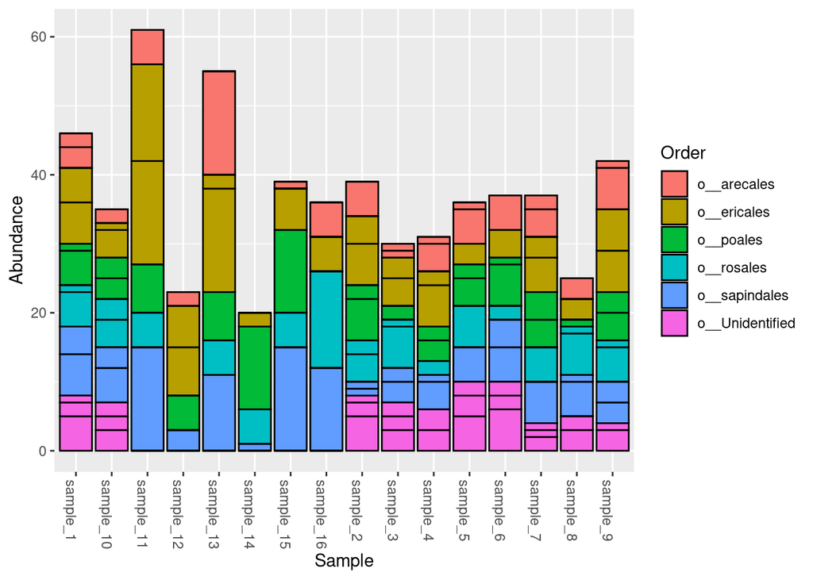

```r
# for instance let's plot a quite ugly barplot
plot_bar(phylo_merged, fill="Order")
```

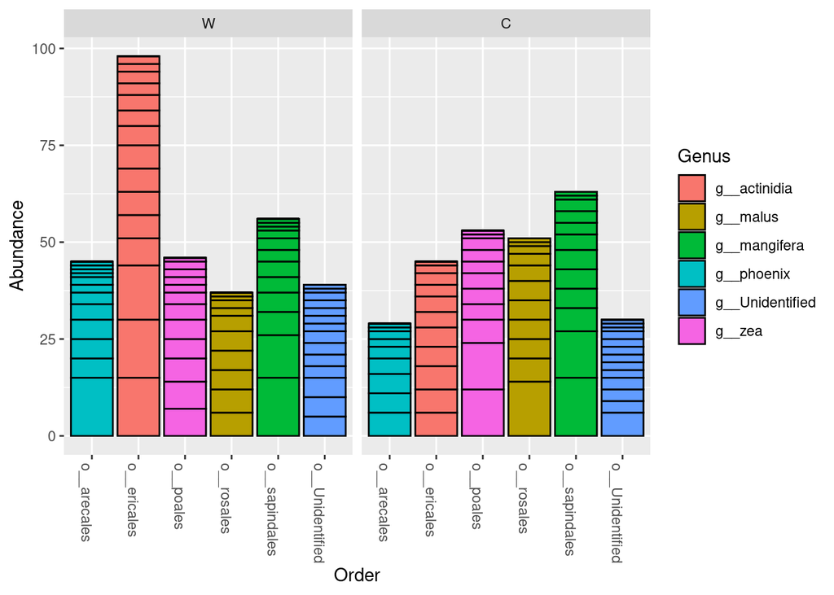

```r
# it is always possible to to better, of course, but not much
# split the plot by Treatment
plot_bar(phylo_merged, "Order", fill="Genus", facet_grid=~Treatment)
```

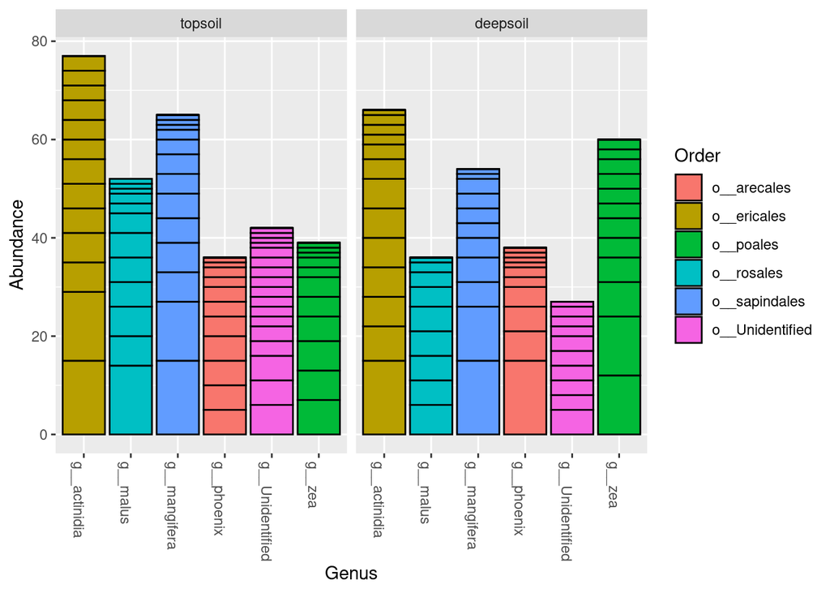

```r
# split the plot by Depth
plot_bar(phylo_merged, "Genus", fill="Order", facet_grid=~Depth)
```

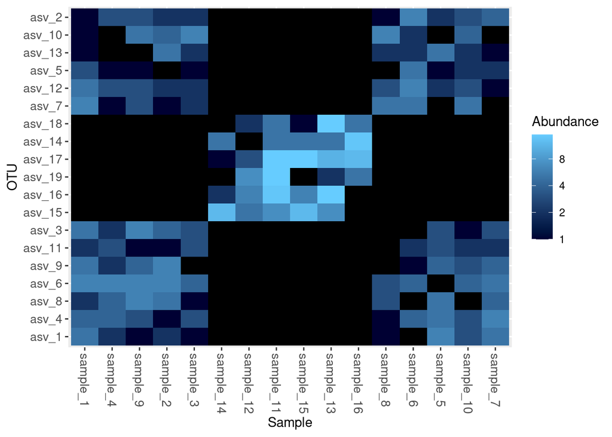

```r
# or a quite not-intuitive heatmap (assuming you have thousands
# of ASVs/OTUS, as is almost always the case)
plot_heatmap(phylo_merged)
```

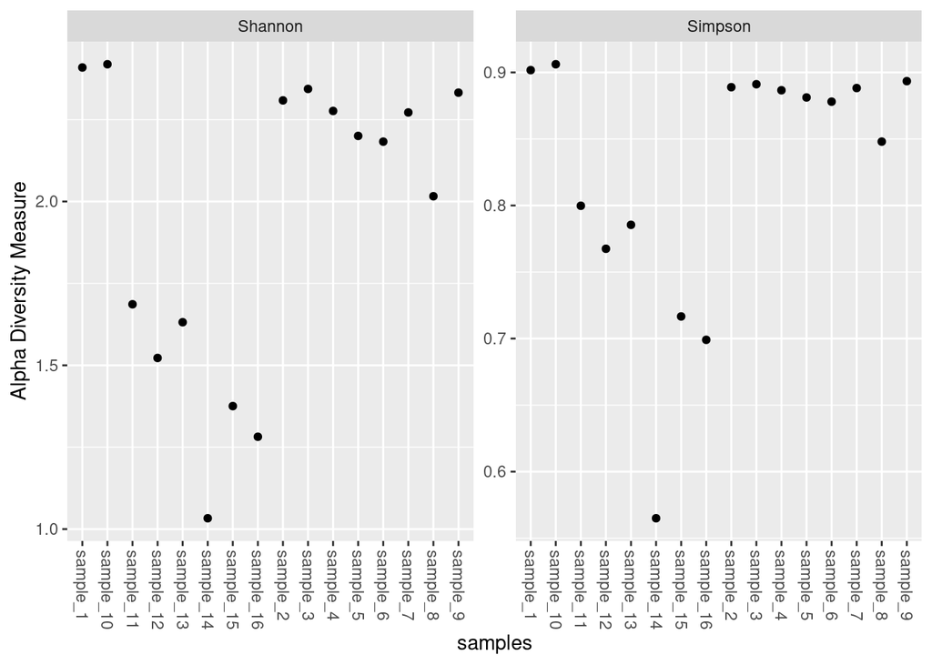

```r
# a phylogenetic tree is also available
# plot_tree(phylo_merged)

# plot alpha diversity
plot_richness(phylo_merged, measures=c("Simpson", "Shannon"))
```

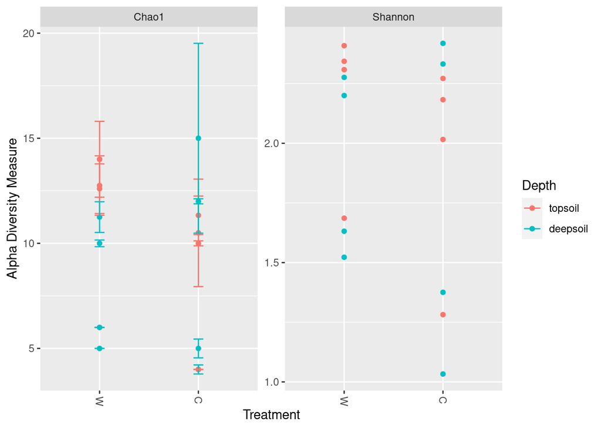

```r
# add colours
plot_richness(phylo_merged, x="Treatment", color="Depth", measures=c("Chao1", "Shannon"))
```

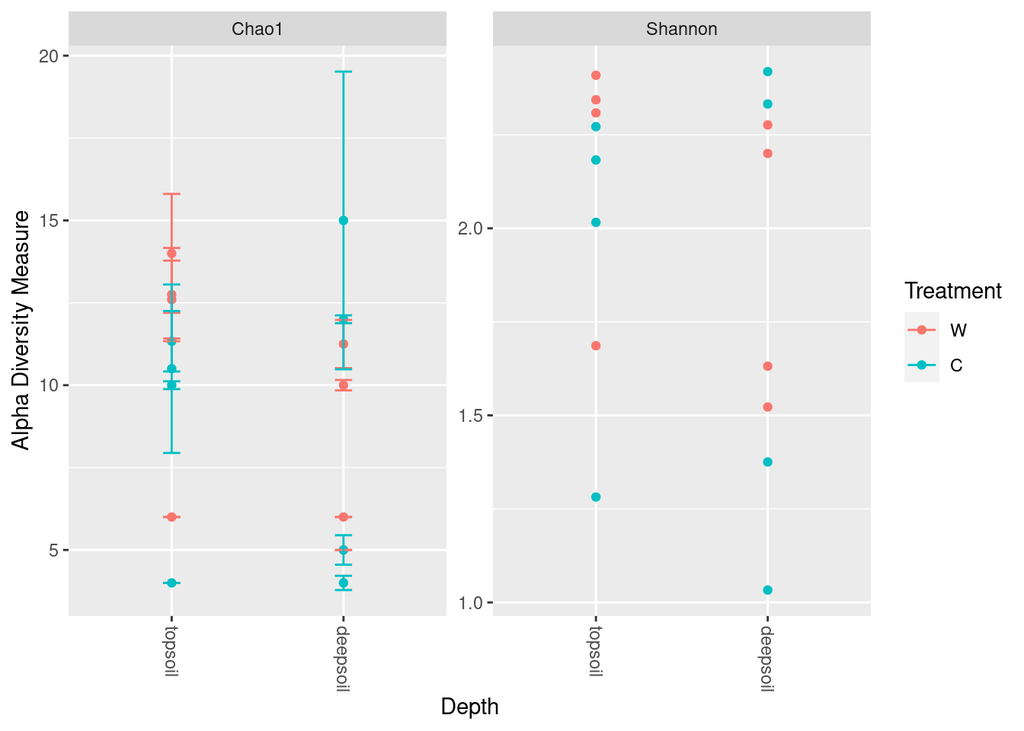

```r
# invert colours and x axis
plot_richness(phylo_merged, x="Depth", color="Treatment", measures=c("Chao1", "Shannon"))
```

These plots are based on `ggplot2` and it is always possible to add further make-up:

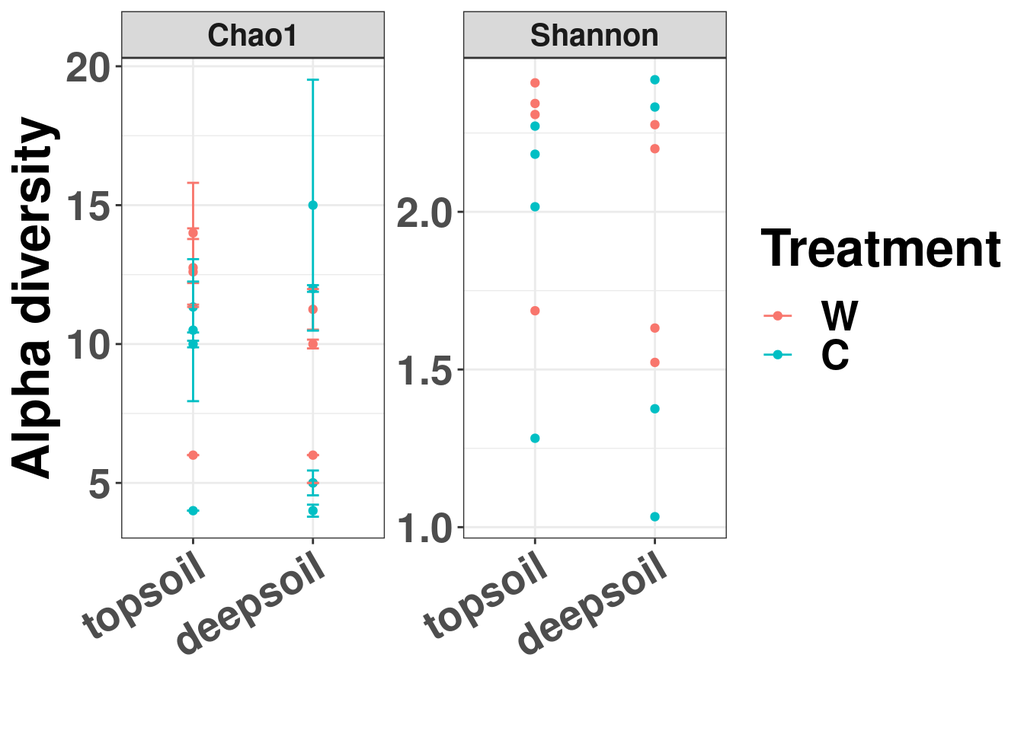

```r
# invert colours and x axis and add some make-up to the plot
plot_richness(phylo_merged, x="Depth", color="Treatment", measures=c("Chao1", "Shannon")) +
  xlab("") +
  ylab("Alpha diversity") +
  theme_bw() +
    theme(text=element_text(size=25, face="bold"), legend.position="right", strip.text=element_text(size=15), axis.text.x=element_text(angle=30, hjust=1))
```

## Basic ordinations

Phyloseq offers the possibility to perform many kinds of ordination using what is called a *wrapper* function, i.e. `ordinate()`.

Ordinations can be perfomed using NMDS or Principal Component Analysis (PCA) or Principal Coordinate Analysis (PCoA) or Redundancy Analysis (RDA) and more…

First, let’s have a look at how the `ordinate()` function works:

```r
help(ordinate)
```

Then, let’s try to run a simple ordination using, for example, PCoA:

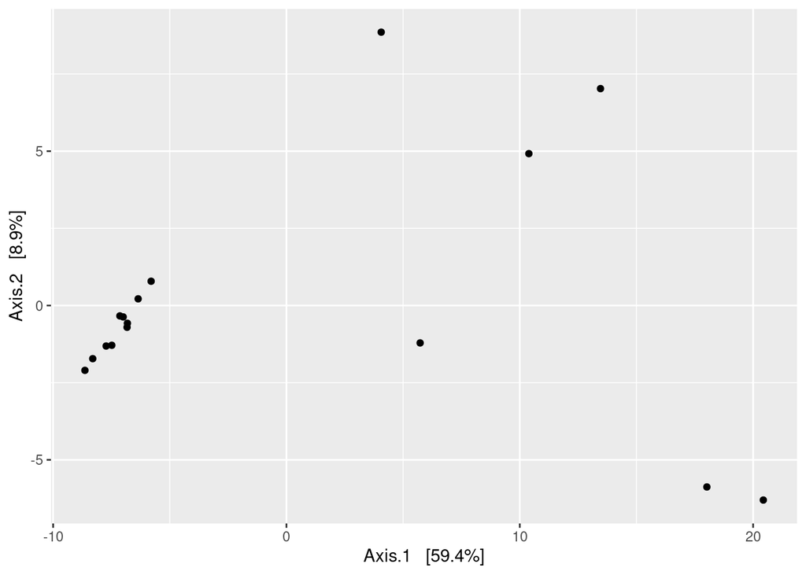

```r
# run a simple ordination
simple_ordination <- ordinate(phylo_merged, "PCoA", "euclidean")

# plot the results
plot_ordination(phylo_merged, simple_ordination)
```

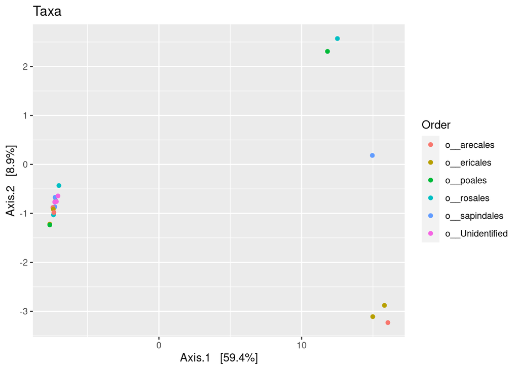

```r
# let's add some colour
plot_ordination(phylo_merged, simple_ordination, type="taxa", color="Order", title="Taxa")
```

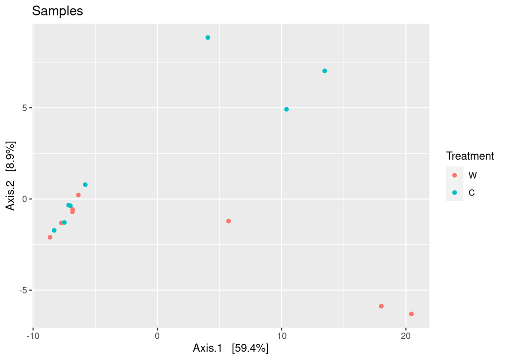

```r
# plot samples only
plot_ordination(phylo_merged, simple_ordination, type="samples", color="Treatment", title="Samples")
```

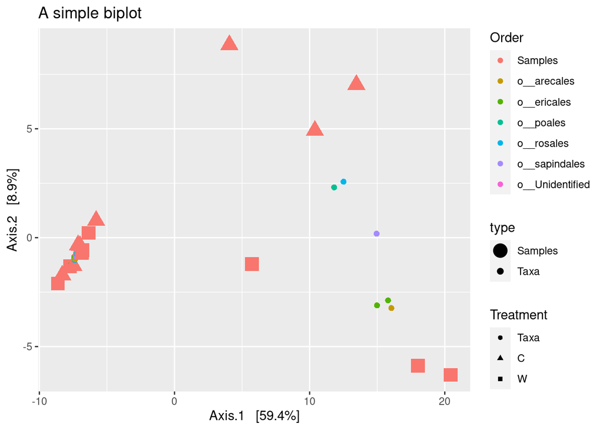

```r
# plot everything at once
plot_ordination(phylo_merged, simple_ordination, type="biplot", color="Order", shape="Treatment", title="A simple biplot")
```

Phyloseq offers the possibility to compute distance matrices and to use them when performing ordination, separately:

```r
# compute distance matrix
a_dist_mat <- distance(phylo_merged, method="euclidean")

# compute ordination using the distance matrix
dist_ordination <- ordinate(phylo_merged, "PCoA", distance=a_dist_mat)
```

Of course, for plotting it is always possible to use `ggplot2`:

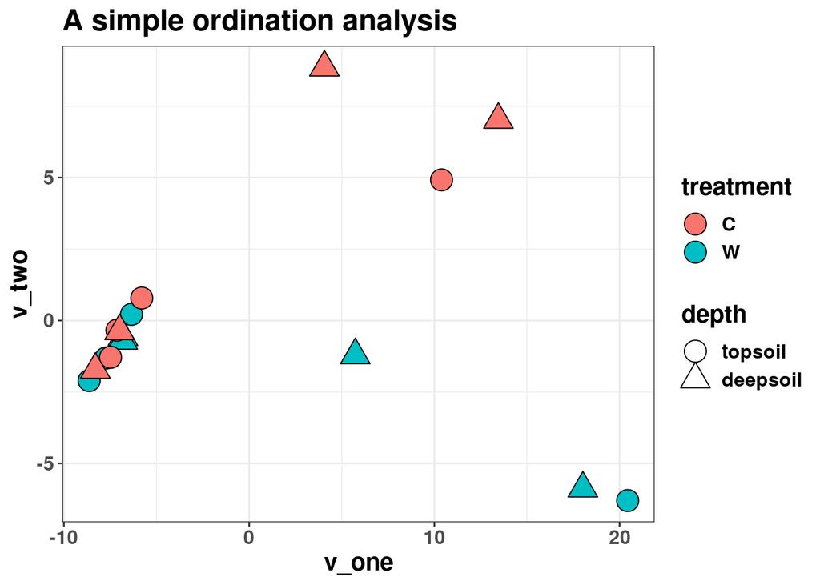

```r
# get first two vectors from the ordination
data_to_plot <- cbind.data.frame(v_one = simple_ordination$vectors[, 1], v_two = simple_ordination$vectors[, 2])

# get further data
treatment <- vector()
depth <- vector()

# for each sample in data
for (ind in c(1:nrow(data_to_plot))) {
    treatment <- append(treatment, as.character(phylo_merged_meta$Treatment[which(phylo_merged_meta$sampleID==rownames(data_to_plot)[ind])]))
    depth <- append(depth, as.character(phylo_merged_meta$Depth[which(phylo_merged_meta$sampleID==rownames(data_to_plot)[ind])]))
    }
# put all together
data_to_plot <- cbind.data.frame(data_to_plot, treatment, depth)
#set levels
data_to_plot$treatment <- factor(data_to_plot$treatment, levels=c("C", "W"))
data_to_plot$depth <- factor(data_to_plot$depth, levels=c("topsoil", "deepsoil"))

# define shapes for depth both shapes must be in the same order
depthshape <- c(21, 24)
names(depthshape) <- c("topsoil", "deepsoil")

# plot without facets
plot_simple <- ggplot(data_to_plot, aes(x=v_one, y=v_two, fill=treatment, shape=depth)) +
    geom_point(size=6) +
    scale_shape_manual(values=depthshape) +
    ggtitle("A simple ordination analysis") +
    theme_bw() +
    theme(text=element_text(size=15, face="bold"), legend.position="right") +
    guides(fill=guide_legend(override.aes=list(shape=21)))

plot(plot_simple)
```

## Constrained ordinations

In addition to simple ordinations, Phyloseq offers the possibility to perform constrained ordination, i.e. partial RDA, for example. To perform this kind of analysis, it is necessary to have some metadata and a model:

```r
# define the model
formula_rda <- "phylo_merged~Treatment+Depth+Condition(Site)"

# compute ordination using the model
partial_rda <- ordinate(phylo_merged, "RDA", formula=as.formula(formula_rda))

# in addition, since the ordinate function of phyloseq is returning
# a vegan object, it is always possible to use a function from vegan
# to add some environmental variables

# compute fitting using vegan
var_fitting_enviro <- envfit(partial_rda, phylo_merged_meta[, c("SOM", "pH")], perm=1000, na.rm=TRUE)

# then, it will be nice to plot the ordination

# load the function files
source("side_functions.R")

# get the plot ready
scaling_two <- function() {plot_ordination(data=partial_rda, metadata=phylo_merged_meta, var_fitting=var_fitting_enviro, scale_param=2, maintitle=paste0("Partial RDA with scaling 2"))}

dev.new(width=40, height=30)

# plot :-)
scaling_two()
```

[output not shown]

## Further explorations

In addition to all the analyses, there are some packages that takes advantage of the Phyloseq data structure. These packages can be used to estimate richness and $\beta$-diversity:

- [Breakaway](https://adw96.github.io/breakaway/index.html);
- DivNet;

or to perform differential abundance analysis:

- [ANCOM-BC](https://github.com/FrederickHuangLin/ANCOMBC).

In contrast, to perform PERMANOVA tests using the `vegan` function `adonis2()`, it is necessary to disassemble the Phyloseq object and use some of its parts.

In the following, some code that plots some barplots and do other stuffs that may be helpful.

```r
############################ LOAD LIBRARIES ############################

# load libraries
library("plyr")
library("dplyr")
```

```r
library("reshape2")
library("ggplot2")
library("phyloseq")
library("ANCOMBC")
############################ LOAD DATA ############################

print("LOADING DATA")

# set path according to the experiment
path_to_exp <- "/mnt/cinqueg/gabriele/work/microbiology/other_analyses/intro_phyloseq/"
# set paths
save_img <- paste0(path_to_exp, "figures/")
save_taxa_figs <- paste0(save_img, "taxaFigs/")

# check if dirs exist
ifelse(!dir.exists(save_img), dir.create(save_img, recursive=TRUE), "dir exists!")
ifelse(dir.exists(save_taxa_figs), "dir exists!", dir.create(save_taxa_figs, recursive=TRUE))

# load asv table
asvs <- read.csv(paste0(path_to_exp, "data/asv_table.csv"), header=T, sep="\t")
metadata <- read.csv(paste0(path_to_exp, "data/metadata.csv"), header=T, sep="\t")
taxonomy <- read.csv(paste0(path_to_exp, "data/taxonomy.csv"), header=T, sep="\t")

############################ CREATE PHYLOSEQ OBJECTS ############################

# set rownames for asvs table
rownames(asvs) <- asvs$asv
# remove first column containing asvs names. it is now useless
asvs <- asvs[, -1]

# set rownamames for taxonomy
rownames(taxonomy) <- taxonomy$asv
taxonomy <- taxonomy[, -1]

# set rownames for metadata
rownames(metadata) <- metadata$sampleID

# load non-transformed object
phylo_data <- phyloseq(otu_table(asvs, taxa_are_rows=T), sample_data(metadata), tax_table(as(taxonomy, "matrix")))

# load metadata table
phylo_metadata <- sample_data(phylo_data)

############################ SELECT PARAMETERS FOR PLOTTING ############################

# loop through taxa levels, to aggregate appropriately
taxa_level <- "Order"
# get best n taxa for the selected taxa_level
n_best <- 3

############################ AGGREGATE ############################

# aggregate taxa at a specific taxonomy level
phylo_aggregated <- tax_glom(phylo_data, taxrank=taxa_level)

# get metadata for phylo_aggregated
phylo_aggregated_meta <- sample_data(phylo_aggregated)

############################ GET INFO NEEDED FOR THE PLOTS ############################

# define empty variable that will store all results for the final plot
control_and_warming_tmp <- list()
unidenti_taxa <- vector()
best_taxa <- vector()
other_taxa <- vector()

# storage for plots
all_plots <- list()

# loop through depths
for (a_depth in unique(phylo_aggregated_meta$Depth)) {

    print(paste0("Analysing ", a_depth))

    # subset by depth. remove samples that do not belong to a specific depth
    phylo_depth <- prune_samples(as.character(phylo_aggregated_meta$sampleID[which(phylo_aggregated_meta$Depth == a_depth)]), phylo_aggregated)

    # remove ASVs which are always zero for the subset under consideration
    phylo_depth <- prune_taxa(taxa_sums(phylo_depth) > 0, phylo_depth)

    # get metadata
    phylo_depth_meta <- sample_data(phylo_depth)

    # compute sums to obtain the contribution of all sampling sites
    # to a specific taxa, then order from most abundant to less abundant
    depth_sums <- sort(rowSums(otu_table(phylo_depth)), decreasing=T)

    # get ordered taxa names, using factors
    taxa_names <- tax_table(phylo_depth)[names(depth_sums), taxa_level]

    # find unidenti, best scoring taxa, and other taxa
    unidenti <- grep("_Unidentified", taxa_names)
    if (length(unidenti)>0){
        # get taxa_names
        unidenti_taxa <- taxa_names[unidenti]
        # remove unidentified taxa
        taxa_names <- taxa_names[-unidenti]
    }
    # get best taxa from those that are identified
    best_taxa <- taxa_names[1:n_best]
    # get all other taxa, from those that are identified
    other_taxa <- taxa_names[(n_best+1):length(taxa_names)]

    # define some empty lists to store all results
    merged_tabs <- vector()
    a_treat_tab <- vector()

    # loop through treatments to compute abundances at treatment level
    for (a_treat in unique(phylo_depth_meta$Treatment)) {

        print(paste0("Analysing ", a_treat))

        # subset by depth
        phylo_treat <- prune_samples(as.character(phylo_depth_meta$sampleID[which(phylo_depth_meta$Treatment == a_treat)]), phylo_depth)

        # remove ASVs which are always zero for the subset under consideration
        phylo_treat <- prune_taxa(taxa_sums(phylo_treat) > 0, phylo_treat)

        for (taxa_type in c("best_taxa", "other_taxa", "unidenti_taxa")) {

            print(paste0("Analysing ", taxa_type))

            taxa_names_sub <- ""

            if (taxa_type=="best_taxa") {
                # get best taxa
                treat_sums <- rowSums(otu_table(phylo_treat)[which(tax_table(phylo_treat)[, taxa_level] %in% get(taxa_type)), ])
                # get taxa names
                taxa_names_sub <- tax_table(phylo_treat)[names(treat_sums), taxa_level]
            } else {

                # compute sums to obtain the contribution of all sampling sites
                # to a specific taxa, then order from most abundant to less abundant
                treat_sums <- sum(rowSums(otu_table(phylo_treat)[which(tax_table(phylo_treat)[, taxa_level] %in% get(taxa_type)), ]))
                # get taxa names
                if (taxa_type=="other_taxa") {
                    taxa_names_sub <- "Other"
                } else {
                    taxa_names_sub <- "Unidentified"
                }
            }

            # put columns together for phylo_depth samples and compute
            # the percentage of contribution each taxa is providing to
            # the total, to finally compare the taxa. by doing so, we
            # make sure the total will always sum up to 1, i.e. 100%
            a_treat_tab <- cbind.data.frame(T_level=taxa_names_sub, Treatment=a_treat, Depth=a_depth, Abundance=treat_sums, Relative=0)
            rownames(a_treat_tab) <- NULL
            colnames(a_treat_tab) <- c("T_level", "Treatment", "Depth", "Abundance", "Relative")
            merged_tabs <- rbind.data.frame(merged_tabs, a_treat_tab)
        }
        # add relative abundance once one treatment is all computed
        merged_tabs[which(merged_tabs$Treatment==a_treat), ]$Relative <- merged_tabs[which(merged_tabs$Treatment==a_treat), ]$Abundance/sum(merged_tabs[which(merged_tabs$Treatment==a_treat), ]$Abundance)
    }

    ############################ SET FACTOR LEVELS ############################

    print("Organising for plots")

    # set levels in order
    last_two <- as.character(c(merged_tabs$T_level[!grepl("Other|Unidenti", merged_tabs$T_level)], merged_tabs$T_level[grepl("Other|Unidenti", merged_tabs$T_level)]))
    merged_tabs$T_level <- factor(merged_tabs$T_level, levels=unique(last_two))

    # re-set labels
    merged_tabs$Treatment <- ifelse(merged_tabs$Treatment=="W", "Warming", "Control")

    # merge depths together
    control_and_warming_tmp[[a_depth]] <- merged_tabs

    ############################ PLOT WITH FACETS ############################

    print("plotting with facets")

    # get the merged_tabs plot ready
    all_plots[[a_depth]] <- merged_tabs %>%
        count(T_level, Treatment, Depth, wt=Relative, name="Relative") %>%
        ggplot() +
        geom_bar(aes(fill=T_level, y=Relative, x=Treatment), stat="identity", color="black") +
        theme_bw() +
        theme(text=element_text(size=25, face="bold"), legend.position="none", strip.text=element_text(size=15), legend.key.height=unit(0.7,'cm'), axis.text.x=element_text(angle=50, hjust=1)) +
        guides(fill=guide_legend(ncol=1)) +
        xlab("") +
        ylab("") +
        facet_wrap(~T_level) +
        ggtitle(paste0("Taxa composition for ", a_depth, " at ", taxa_level, " level"))
}

############################ SET FACTORS LEVELS ############################

control_and_warming <- do.call(rbind.data.frame, control_and_warming_tmp)

# set levels for T_level
last_two <- as.character(c(control_and_warming$T_level[!grepl("^Other$|^Unidenti$", control_and_warming$T_level)], control_and_warming$T_level[grepl("^Other$|^Unidenti$", control_and_warming$T_level)]))
control_and_warming$T_level <- factor(control_and_warming$T_level, levels=unique(last_two))

# set levels for Depth
control_and_warming$Depth <- factor(control_and_warming$Depth, levels=unique(control_and_warming$Depth))

############################ PLOT STACKED ############################

print("plot stacked")

# get the plot ready
all_plots[["ribon"]] <- control_and_warming %>%
    count(T_level, Treatment, Depth, wt=Relative, name="Relative") %>%
    ggplot() +
    geom_bar(aes(fill=T_level, y=Relative, x=Treatment), position="fill", stat="identity", color="black") +
    theme_bw() +
    theme(text=element_text(size=25, face="bold"), legend.position="right", legend.text=element_text(size=15), legend.key.height=unit(0.7,'cm'), axis.text.x=element_text(angle=50, hjust=1)) +
    guides(fill=guide_legend(ncol=1)) +
    xlab("") +
    ylab("") +
    ylim(0, 1) +
    facet_wrap(~Depth) +
    labs(fill=taxa_level)
```

## PERMANOVA with Adonis2

Here some statistics using the permutational anova, i.e. PERMANOVA, test which is implemented, inside the `vegan` package, by a function called `adonis2()`.

```r
############################ PERMANOVA TEST WITH ADONIS2 ############################

# as factors
phylo_merged_meta$Treatment <- factor(phylo_merged_meta$Treatment, levels=unique(phylo_merged_meta$Treatment))

# set levels to make Controls the reference
phylo_merged_meta$Treatment <- relevel(phylo_merged_meta$Treatment, ref="C")

# get taxa table and transpose it in to obtain a table which is
# sample X species as described in the Adonis documentation
# https://rdrr.io/rforge/vegan/man/adonis.html
transposed_taxa <- t(otu_table(phylo_merged))

# get metadata
adonis_meta <- as.data.frame(as.matrix(phylo_merged_meta))

# make sure the variables in the formula are factors since
# statistical models require it, to work properly
adonis_meta$Treatment <- factor(adonis_meta$Treatment, levels=unique(adonis_meta$Treatment))
adonis_meta$Depth <- factor(adonis_meta$Depth, levels=unique(adonis_meta$Depth))
adonis_meta$Site <- factor(adonis_meta$Site, levels=unique(adonis_meta$Site))

# set seed
set.seed(131)

# using adonis2 to perform the analysis

# set number of permutations
permuts <- how(nperm = 999)

# set blocking variable, i.e. the sampling sites
adonis_meta$Site <- as.factor(adonis_meta$Site)

# run adonis2 on bray-curtis distance using Site
# as blocking factor
# BE CAREFUL HERE, I AM NOT SURE ABOUT THIS WORKING AS I AM EXPECTING
adonis_test <- adonis2(transposed_taxa~Treatment*Depth, data=adonis_meta, permutations=permuts, strata=adonis_meta$Site, method="bray", by="terms")
```

## Differential abundance with LinDA

This is an example of differential abundance analysis, i.e. what may be done using EdgeR or DESeq2, but using a package called LinDA. To use the `linda()` function you will need to install this package: [MicrobiomeStat](https://cran.r-project.org/web/packages/MicrobiomeStat/index.html).

For setting proper thresholds, this is a suggested reading about [log-fold change](https://www.biostars.org/p/342756/).

```r
############################ DIFFERENTIAL ABUNDANCE ANALYSIS ############################ies
# load libraries
library("MicrobiomeStat")
```

```r
library("dplyr")
library("ggrepel")

# set threshold for significance of p-adjusted. should be 0.05
# here it's set as 0.5 just to show some taxa
signif_t <- 0.5
# set threshold for log-fold-change. usually it is set at 1 or 2
# here it's set as 0.5 just to show some DA taxa
lfc_thresh <- 0.5
# set threshold for p-value and compute it's value in log10 scale
# to plot a dashed line in the volcano plot
p_thresh <- abs(log10(signif_t))
# set threshold for abundances
abundance_threshold <- 0.01

# set level to investigate
taxa_level <- "Genus"

# storage for all results
all_res <- list()

# set variables of interests as factor
# first level will be the one used by ANCOMBC as a reference level for the analysis
sample_data(phylo_merged)$Treatment <- factor(sample_data(phylo_merged)$Treatment, levels=c("C", "W"))
# set levels to compare to
ref_lev_treat <- "C"
sample_data(phylo_merged)$Treatment <- relevel(sample_data(phylo_merged)$Treatment, ref_lev_treat)
sample_data(phylo_merged)$Depth <- factor(sample_data(phylo_merged)$Depth, levels=c("topsoil", "deepsoil"))
# set levels to compare to
ref_lev_depth <- "topsoil"
sample_data(phylo_merged)$Depth <- relevel(sample_data(phylo_merged)$Depth, ref_lev_depth)
sample_data(phylo_merged)$Site <- factor(sample_data(phylo_merged)$Site, levels=unique(sample_data(phylo_merged)$Site))

print(paste0("treat by time at ", taxa_level, " level"))

# agglomerate phylo at ASV level
if (taxa_level=="ASV") {
  # and leave the table as is
  phylo_agg <- phylo_merged
} else {
  # otherwise, for any other level, aggregate
  phylo_agg <- tax_glom(phylo_merged, taxrank=taxa_level)
}

# compute abundances
phylo_abundances <- otu_table(transform_sample_counts(phylo_agg, function(x) x / sum(x)))
# threshold for DA analysis. this will return taxa above the abundance threshold
above_thres_taxa <- rownames(phylo_abundances[rowSums(phylo_abundances)>=abundance_threshold, ]) ; updown <- "above"
# threshold for DA analysis. this will return taxa above the abundance threshold
#above_thres_taxa <- rownames(phylo_abundances[rowSums(phylo_abundances)<=abundance_threshold, ]) ; updown <- "below"

# if thresholding use this
#otu_data <- as(otu_table(phylo_agg), "matrix")[above_thres_taxa, ]

# if not thresholding use this
otu_data <- as(otu_table(phylo_agg), "matrix")

# get metadata
metadata <- as(sample_data(phylo_agg), "data.frame")

# set seed
set.seed(131)

# run linda
linda_outs <- linda(otu_data, metadata, formula = '~Treatment+Depth+(1|Site)', alpha=signif_t, prev.filter=0.06, n.cores=4) ; withint <- ""
```

```
## boundary (singular) fit: see help('isSingular')
```

```r
# show the available tables generated by linda
print(names(linda_outs$output))
```

[output not shown]

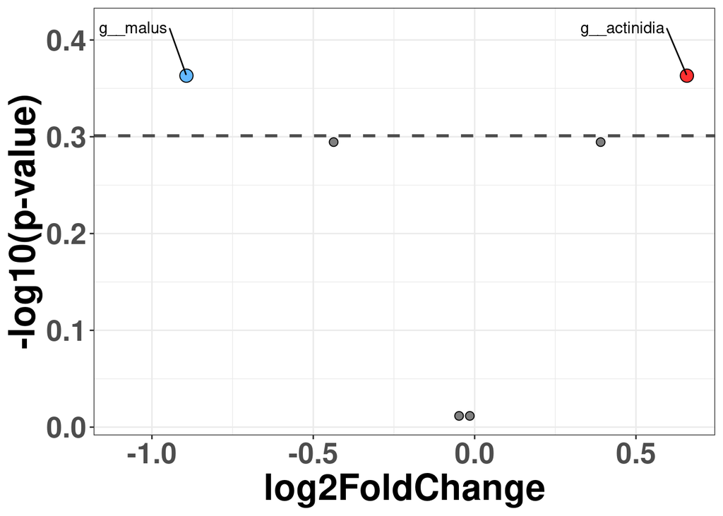

```r
# get results from one of the linda outputs
which_tab <- "TreatmentW"

# get table
volcano_data <- linda_outs$output[[which_tab]]

# create label describing Depth, and taxa level
lbl <- paste0(updown, "_", abundance_threshold, "_", ref_lev_depth, "_", ref_lev_treat, "_", taxa_level, "_test_", which_tab)

# store results
all_res[[lbl]] <- linda_outs

# get taxa names for plotting purposes
if (taxa_level=="ASV") {
  # if taxa_level is set at ASV level, get Genus level names
  volcano_data$taxa <-  as(tax_table(phylo_agg)[which(rownames(tax_table(phylo_agg)) %in% rownames(volcano_data)), "Genus"], "character")
} else {
  # get taxa names at correct taxa level
  volcano_data$taxa <-  as(tax_table(phylo_agg)[which(rownames(tax_table(phylo_agg)) %in% rownames(volcano_data)), taxa_level], "character")
}

# if any result is available, plot
if (any(volcano_data$log2FoldChange >= lfc_thresh & volcano_data$padj <= signif_t | volcano_data$log2FoldChange <= -lfc_thresh  & volcano_data$padj <= signif_t)) {

  # apply threshold on p-values and log-fold change
  volcano_data <- volcano_data %>% mutate(threshold = ifelse(log2FoldChange >= lfc_thresh & padj <= signif_t,"up", ifelse(log2FoldChange <= -lfc_thresh  & padj <= signif_t, "down", "other")))
  volcano_data <- volcano_data %>% mutate(dsize=ifelse(log2FoldChange >= lfc_thresh & padj <= signif_t, 4, ifelse(log2FoldChange <= -lfc_thresh  & padj <= signif_t, 4, 2.5)))
  # compute log of padj
  volcano_data$log_p <- abs(log10(volcano_data$padj))

  # unlabel non significant taxa, if any was found
  if (any(volcano_data$threshold=="other") | length(grep("Unidentified", volcano_data$taxa))>0) {
    volcano_data$taxa[which(volcano_data$threshold=="other")] <- ""
    volcano_data$taxa[grep("Unidentified", volcano_data$taxa)] <- ""
  }

  # plot
  volcano <- ggplot(volcano_data, aes(x=log2FoldChange, y=log_p, label=taxa)) +
    geom_point(aes(fill=threshold), shape=21, colour="black", size=volcano_data$dsize) +
    scale_fill_manual(values = c("up"="firebrick1", "down"="steelblue1",  "other"= "gray50")) +
    geom_hline(yintercept=p_thresh, linetype="dashed", color = "gray30", linewidth=1) +
    geom_text_repel(nudge_x=-0.2, nudge_y=0.05, max.overlaps=20) +
    ylab("-log10(p-value)") +
    xlab("log2FoldChange") +
    theme_bw() +
    theme(text=element_text(size=25, face="bold"), legend.position="none", strip.text=element_text(size=15), legend.key.height=unit(0.7,'cm'))

  # plot
  plot(volcano)

} else {
  print("nothing significant!")
}
```

In this plot, the dashed line represents the p-value threshold, in log10-scale (to show which taxa are statisticall significant). The plots shows the comparison of W versus C:

- malus (on the left side, in blue) is less abundant in W than in C;
- actinidia (on the right side, in red) is more abundant in W than in C.

There are many other ways of computing differentially abundant taxa such as [ANCOM-BC](https://github.com/FrederickHuangLin/ANCOMBC) and others, see [this](https://doi.org/10.1093/bib/bbac607) paper and [this](https://doi.org/10.1186/s40168-022-01320-0) paper for some inspiration.